# Assignment Four

Arian, Anne

11 12 2020

```r
library(modelr)
library(lubridate)
library(tidyverse)
library(broom)
library(PxWebApiData)
```

```r
library(ggplot2)
```

# Models

## Loading the data

```r
arblos <- read_csv("data/al9914m.csv")
bef <- read_csv("data/bef9914MK.csv")
```

## Modeller med data fra *bef* (befolkning)

```r
names(bef)
```

```
##  [1] "knr"           "knavn"         "aar"           "bef_K_0_14"
##  [5] "bef_K_15_29"   "bef_K_30_74"   "bef_K_75_105"  "bef_M_0_14"
##  [9] "bef_M_15_29"   "bef_M_30_74"   "bef_M_75_105"  "bef_MK_0_14"
## [13] "bef_MK_15_29"  "bef_MK_30_74"  "bef_MK_75_105"
```

```r
names(arblos)
```

```
##  [1] "knr"         "knavn"       "aar"         "mnd"         "al_Menn"
##  [6] "al_Kvinner"  "alp_Menn"    "alp_Kvinner" "alp_15_74"   "alp_15_29"
## [11] "alp_30_74"
```

Arbeidsledighetsprosenten blir beregnet som: arbl% = antall arb. ledige/arbeidsstyrken. Arbeidsstyrken er her dem man anser egnet for arbeid dvs. uføretrygdete etc. er trukket ut. Arbeidsstyren i en aldesrkategori er derfor langt mindre enn befolkningen i den tilsvarende alderskategorien.

Dessverre kjenne vi ikke arbeidsstyrken, men vi kan beregne den vha.: arbeidsstyrken = antall arb. ledige/arb. ledighetsprosent.

```r
arblos <- arblos %>%
    mutate(
        wf_K = (al_Kvinner/alp_Kvinner)*100,
        wf_M = (al_Menn/alp_Menn)*100,
        wf_KM = wf_K + wf_M
    )
```

```r
arblos
```

```
## # A tibble: 77,330 x 14
##    knr   knavn   aar   mnd al_Menn al_Kvinner alp_Menn alp_Kvinner alp_15_74
##    <chr> <chr> <dbl> <dbl>   <dbl>      <dbl>    <dbl>       <dbl>     <dbl>
##  1 0101  Hald~  1999     1     283        248      3.9         4.1       4
##  2 0101  Hald~  1999     2     291        236      4           3.9       4
##  3 0101  Hald~  1999     3     290        230      4           3.8       3.9
##  4 0101  Hald~  1999     4     244        207      3.4         3.4       3.4
##  5 0101  Hald~  1999     5     210        179      2.9         3         2.9
##  6 0101  Hald~  1999     6     227        203      3.2         3.4       3.2
##  7 0101  Hald~  1999     7     265        273      3.7         4.5       4.1
##  8 0101  Hald~  1999     8     288        278      4           4.6       4.3
##  9 0101  Hald~  1999     9     230        201      3.2         3.3       3.3
## 10 0101  Hald~  1999    10     225        207      3.1         3.4       3.3
## # ... with 77,320 more rows, and 5 more variables: alp_15_29 <dbl>,
## #   alp_30_74 <dbl>, wf_K <dbl>, wf_M <dbl>, wf_KM <dbl>
```

## Arbeidsstyrken

Når befolkningen øker vil også arbeidsstyrken øke. Det er derfor mer naturlig å se på arbeidsstyrken relativt til delen av befolkningen som er i yrkesaktiv alder (15-74 år her).

```r
names(bef)
```

```
##  [1] "knr"           "knavn"         "aar"           "bef_K_0_14"
##  [5] "bef_K_15_29"   "bef_K_30_74"   "bef_K_75_105"  "bef_M_0_14"
##  [9] "bef_M_15_29"   "bef_M_30_74"   "bef_M_75_105"  "bef_MK_0_14"
## [13] "bef_MK_15_29"  "bef_MK_30_74"  "bef_MK_75_105"
```

Vi skal starte med å lage et datasett med arbeidsstyrken (wf) for hele landet samlet, men fordelt på de tre kategorien kvinner, menn og kvinner + menn.

Bruk data for januar hvert år til å beregne wf på landsbasis

```r
# årlige data landet samlet
wf <- arblos %>%
    filter(mnd == 1) %>%
    group_by(aar) %>%
    summarise(
        wf_K = sum(wf_K, na.rm = TRUE),
        wf_M = sum(wf_M, na.rm = TRUE),
        wf_KM = wf_K + wf_M
    )
dim(wf)
```

```
## [1] 16  4
```

```r
names(wf)
```

```
## [1] "aar"   "wf_K"  "wf_M"  "wf_KM"
```

Summer de ulike årskategoriene for de to kjønnene og menn+kvinner for å finne total befolkning de ulike årene. Bruk mutate til å lage de nye variablene.

```r
dim(bef)
```

```
## [1] 6688   18
```

```r
names(bef)
```

```
##  [1] "knr"           "knavn"         "aar"           "bef_K_0_14"
##  [5] "bef_K_15_29"   "bef_K_30_74"   "bef_K_75_105"  "bef_M_0_14"
##  [9] "bef_M_15_29"   "bef_M_30_74"   "bef_M_75_105"  "bef_MK_0_14"
## [13] "bef_MK_15_29"  "bef_MK_30_74"  "bef_MK_75_105" "bef_K"
## [17] "bef_M"         "bef_KM"
```

Legg befolkningsdata varaiablene bef_K, bef_M, bef_KM til wf. Husk at de må aggregeres for hele landet (group_by() og så summarise() før de «joines»). Bruk tilslutt mutate() make_date() for å lage en ny variabel år som er en date, dvs aar + month=1L + day=1L.

Da skal du få

```r
wf
```

```
## # A tibble: 16 x 8
##      aar     wf_K     wf_M    wf_KM   bef_K   bef_M  bef_KM år
##    <dbl>    <dbl>    <dbl>    <dbl>   <dbl>   <dbl>   <dbl> <date>
##  1  1999 1031744. 1205745. 2237489. 2172270 2128101 2128101 1999-01-01
##  2  2000 1037097. 1207206. 2244303. 2187760 2145401 2145401 2000-01-01
##  3  2001 1049731. 1218061. 2267791. 2198085 2159014 2159014 2001-01-01
##  4  2002 1061392. 1221762. 2283154. 2207743 2169466 2169466 2002-01-01
##  5  2003 1077983. 1219325. 2297307. 2221543 2183278 2183278 2003-01-01
##  6  2004 1079308. 1221288. 2300596. 2233444 2195946 2195946 2004-01-01
##  7  2005 1081663. 1225478. 2307142. 2247678 2211290 2211290 2005-01-01
##  8  2006 1089654. 1233306. 2322960. 2263342 2228683 2228683 2006-01-01
##  9  2007 1103816. 1249628. 2353444. 2280147 2252098 2252098 2007-01-01
## 10  2008 1132662. 1271414. 2404076. 2301949 2285368 2285368 2008-01-01
## 11  2009 1172942. 1323707. 2496649. 2328143 2319883 2319883 2009-01-01
## 12  2010 1179755. 1318575. 2498330. 2354699 2350920 2350920 2010-01-01
## 13  2011 1181768. 1330901. 2512669. 2381939 2384191 2384191 2011-01-01
## 14  2012 1194903. 1342914. 2537817. 2408715 2421079 2421079 2012-01-01
## 15  2013 1212788. 1365955. 2578743. 2436406 2457056 2457056 2013-01-01
## 16  2014 1230477. 1381665. 2612141. 2462194 2487875 2487875 2014-01-01
```

Vi vil nå se på arbeidsstyrke relativt til befolkning på landsbasis, dvs. wf_K/bef_K etc. Plot dataen vha. geom_line() for de tre kategoriene. Bruk år som x-variabel.

[figure not shown]

Hvordan kan pukkelen rett før 2010 forklares?

```r
names(arblos)
```

```
##  [1] "knr"         "knavn"       "aar"         "mnd"         "al_Menn"
##  [6] "al_Kvinner"  "alp_Menn"    "alp_Kvinner" "alp_15_74"   "alp_15_29"
## [11] "alp_30_74"   "wf_K"        "wf_M"        "wf_KM"
```

Vi vil nå generere data for arbeidsstyrken på fylkesbasis. Husk at de to første sifrene i knr angir fylket en kommune ligger i. Bruk dataene i arblos til å finne arbeidsstyrken på fylkesbasis (wf_f). Start med å bruke mutate() til å lage en ny variabel fylke. Grupper så og finn wf_K_f, wf_M_f og wf_KM_f vha. summarise(). Lag til slutt en ny variabel år som en date. Velg til slutt de relevante variabelen vha. select().

```r
# årlige data per fylke
wf_f <- arblos %>%
    mutate(
        fylke = substr(knr, start = 1, stop = 2)
    ) %>%
    group_by(aar, mnd, fylke) %>%
    summarise(
        wf_K_f = sum(wf_K, na.rm = TRUE),
        wf_M_f = sum(wf_M, na.rm = TRUE),
        wf_KM_f = wf_K_f + wf_M_f
    ) %>%
    mutate(år = make_date(aar, mnd, day=1L)) %>%
    select(aar, mnd, år, fylke, wf_K_f, wf_M_f, wf_KM_f)
```

Vi skal nå ha en tibble wf_f som ser slik ut:

```r
print(wf_f, n = 5)
```

```
## # A tibble: 3,515 x 7
## # Groups:   aar, mnd [185]
##     aar   mnd år         fylke  wf_K_f  wf_M_f wf_KM_f
##   <dbl> <dbl> <date>     <chr>   <dbl>   <dbl>   <dbl>
## 1  1999     1 1999-01-01 01     57671.  67408. 125079.
## 2  1999     1 1999-01-01 02    120670. 133018. 253688.
## 3  1999     1 1999-01-01 03    133500  147097. 280597.
## 4  1999     1 1999-01-01 04     42237.  49356.  91593.
## 5  1999     1 1999-01-01 05     41178.  47990.  89168.
## # ... with 3,510 more rows
```

Lag også en ny tibble bef_f fra bef som inneholder befolkningen i hvert fylke hvert år.

```r
bef_f
```

```
## # A tibble: 304 x 5
## # Groups:   aar [16]
##      aar fylke bef_K_f bef_M_f bef_KM_f
##    <dbl> <chr>   <dbl>   <dbl>    <dbl>
##  1  1999 01     125278  120740   246018
##  2  1999 02     232564  228000   460564
##  3  1999 03     260639  242228   502867
##  4  1999 04      94239   92082   186321
##  5  1999 05      88898   87363   176261
##  6  1999 06     119096  115922   235018
##  7  1999 07      73772   70920   144692
##  8  1999 08      83559   80964   164523
##  9  1999 09      50994   50493   101487
## 10  1999 10      77789   76209   153998
## # ... with 294 more rows
```

Lag til slutt tibble-en wf_f_bef som innholde arbeidsstyrke (wf-f) og befolkning (bef-f) på fylkesnivå for hvert år.

Da skal wf_f_bef se slik ut:

```r
print(arrange(wf_f_bef, fylke, aar, mnd))
```

```
## # A tibble: 3,515 x 10
## # Groups:   aar, mnd [185]
##      aar   mnd år         fylke wf_K_f wf_M_f wf_KM_f bef_K_f bef_M_f bef_KM_f
##    <dbl> <dbl> <date>     <chr>  <dbl>  <dbl>   <dbl>   <dbl>   <dbl>    <dbl>
##  1  1999     1 1999-01-01 01    57671. 67408. 125079.  125278  120740   246018
##  2  1999     2 1999-02-01 01    57693. 67526. 125220.  125278  120740   246018
##  3  1999     3 1999-03-01 01    57108. 67551. 124659.  125278  120740   246018
##  4  1999     4 1999-04-01 01    57526. 67355. 124881.  125278  120740   246018
##  5  1999     5 1999-05-01 01    57285. 67189. 124474.  125278  120740   246018
##  6  1999     6 1999-06-01 01    57529. 66792. 124321.  125278  120740   246018
##  7  1999     7 1999-07-01 01    57393. 67690. 125083.  125278  120740   246018
##  8  1999     8 1999-08-01 01    57531. 66998. 124529.  125278  120740   246018
##  9  1999     9 1999-09-01 01    57264. 67609. 124873.  125278  120740   246018
## 10  1999    10 1999-10-01 01    57702. 66907. 124610.  125278  120740   246018
## # ... with 3,505 more rows
```

Plot nå arbeidsstyrke relativt til befolkning vha. geom_line()

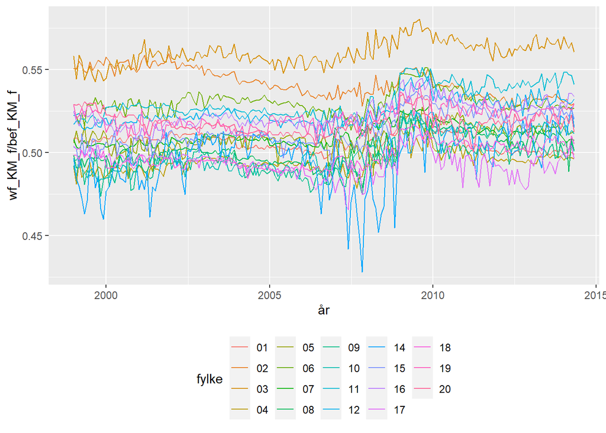

### Lage regioner

Alle fylkene blir litt rotete så vi definerer istedet seks regioner vha. case_when() og lager en ny tibble wf_r fra wf_f_bef.

```r
# region
wf_r <- wf_f_bef %>%
    mutate(
         dato = ymd(paste(aar, mnd, "01", sep = "-")),
        region = case_when(
            as.numeric(fylke) == 3 ~ "Oslo",
            as.numeric(fylke) %in% c(1:2, 4:8) ~ "Østlandet",
            as.numeric(fylke) %in% c(9, 10) ~ "Sørlandet",
            as.numeric(fylke) %in% c(11, 12, 14, 15) ~ "Vestlandet",
            as.numeric(fylke) %in% c(16, 17) ~ "Trøndelag",
            as.numeric(fylke) %in% c(18, 19, 20) ~ "Nord-Norge"
        )
    ) %>%
    group_by(dato, region) %>%
    summarise(
        wf_K_r = sum(wf_K_f, na.rm = TRUE),
        wf_M_r = sum(wf_M_f, na.rm = TRUE),
        wf_KM_r = wf_K_r + wf_M_r,
        bef_K_r = sum(bef_K_f, na.rm = TRUE),
        bef_M_r = sum(bef_M_f, na.rm = TRUE),
        bef_KM_r = bef_K_r + bef_M_r
    ) %>%
    select(dato, region, wf_K_r, wf_M_r, wf_KM_r, bef_K_r, bef_M_r, bef_KM_r)
```

Plot nå for regionene wf_KM_r/bef_KM_r, både vha. geom_line() og geom_smooth(). La farge vise regionene. Sett denne i ggplot() slik at det gjelder for både geom_line() og geom_smooth(). Sett i tillegg alpha = 0.5 for geom_line() og se = FALSE for geom_smooth(). Legg til theme(legend.position = “bottom”) til slutt for å få legend under plottet.

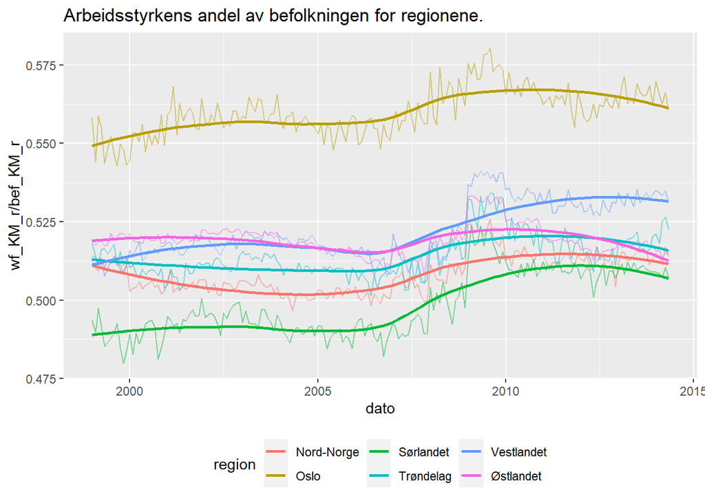

Lag tilsvarende plot for kvinner.

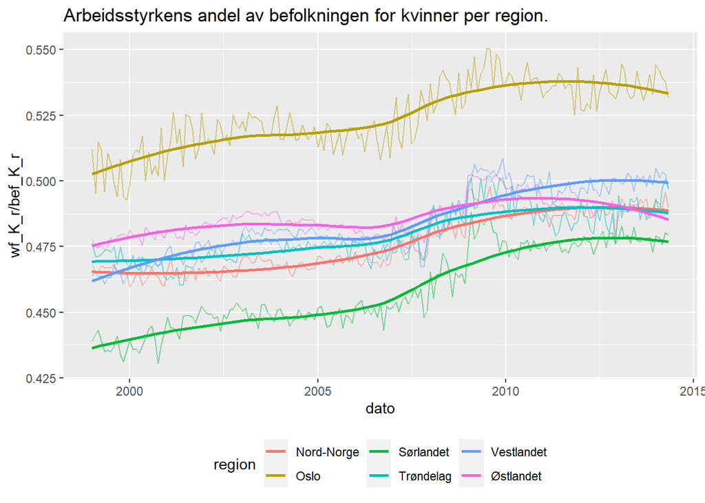

Lag tilsvarende plot for menn

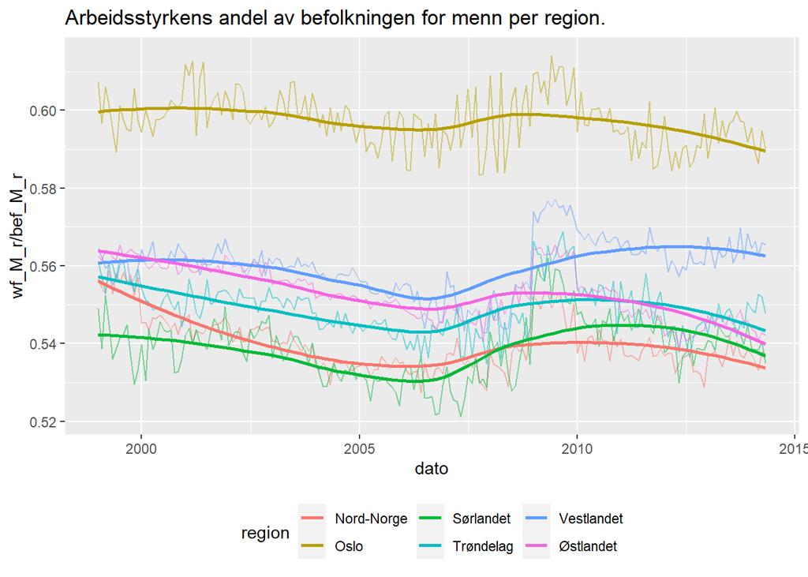

Forlar kort den generelle utviklingen i arbeidsstyrken. Hva er det som «redder oss»?

## `nest()` arblos

Da skal vi jobbe direkte med arbeidsløshet og lage lineære modeller for hver av de 418 kommunene. Modellen vi skal lage er på ingen måte perfekt. Vi er interessert i selve teknikken med å organisere dataene og kjøre modeller på mange subsett av dataene (her for hver kommune).

Vi vil se på en modell der vi forklarer arbeidsstyrken i en kommune vha. ungdomsledighet og ledighet blant litt eldre arbeidstakere (30-74 år). En hypotese er at vi vil se en negativ sammenheng mellom ungdomsledighet og arbeidsstyrken. De unge flytter hvis det ikke er jobb.

Vi starter med å gruppere på kommune og nest-e dataene.

```r
arblos_by_knr <- arblos %>%
    group_by(knr, knavn) %>%
    nest()
```

```r
print(arblos_by_knr, n = 4)
```

```
## # A tibble: 418 x 3
## # Groups:   knr, knavn [418]
##   knr   knavn       data
##   <chr> <chr>       <list>
## 1 0101  Halden      <tibble [185 x 12]>
## 2 0104  Moss        <tibble [185 x 12]>
## 3 0105  Sarpsborg   <tibble [185 x 12]>
## 4 0106  Fredrikstad <tibble [185 x 12]>
## # ... with 414 more rows
```

```r
arblos_by_knr$data[[1]]
```

```
## # A tibble: 185 x 12
##      aar   mnd al_Menn al_Kvinner alp_Menn alp_Kvinner alp_15_74 alp_15_29
##    <dbl> <dbl>   <dbl>      <dbl>    <dbl>       <dbl>     <dbl>     <dbl>
##  1  1999     1     283        248      3.9         4.1       4         6.3
##  2  1999     2     291        236      4           3.9       4         6.1
##  3  1999     3     290        230      4           3.8       3.9       5.9
##  4  1999     4     244        207      3.4         3.4       3.4       4.9
##  5  1999     5     210        179      2.9         3         2.9       3.8
##  6  1999     6     227        203      3.2         3.4       3.2       4.2
##  7  1999     7     265        273      3.7         4.5       4.1       5.2
##  8  1999     8     288        278      4           4.6       4.3       6.6
##  9  1999     9     230        201      3.2         3.3       3.3       4.8
## 10  1999    10     225        207      3.1         3.4       3.3       4.8
## # ... with 175 more rows, and 4 more variables: alp_30_74 <dbl>, wf_K <dbl>,
## #   wf_M <dbl>, wf_KM <dbl>
```

Vi har nå en tibble med data for hver kommune inne i tibble-en arblos_by_knr.

Skriv en funksjon som kjører den lineære modellen wf_KM ~ alp_15_29 + alp_30_74 på en input dataframe a_df. Kall funksjonen mod1 (i magel på noe bedre navn).

KJøre så modellen vha. funksjonen mod1 på data i arblos_by_knr, og lag en list-column i arblos_by_knr som inneholder modellen. Kjør også tidy og glance fra broom på modellene for å få hhv. koeffisienter og ulike summary av modellen. Lagre resultatene i hhv. mod1_arblos, mod1_arblos_coef og mod1_arblos_sum (i siste er sum forkortelse for summary)

arblos_by_knr skal nå se ut slik:

```r
arblos_by_knr
```

```
## # A tibble: 418 x 6
## # Groups:   knr, knavn [418]
##    knr   knavn      data           mod1_arblos mod1_arblos_coef mod1_arblos_sum
##    <chr> <chr>      <list>         <list>      <list>           <list>
##  1 0101  Halden     <tibble [185 ~ <lm>        <tibble [3 x 5]> <tibble [1 x 12~
##  2 0104  Moss       <tibble [185 ~ <lm>        <tibble [3 x 5]> <tibble [1 x 12~
##  3 0105  Sarpsborg  <tibble [185 ~ <lm>        <tibble [3 x 5]> <tibble [1 x 12~
##  4 0106  Fredrikst~ <tibble [185 ~ <lm>        <tibble [3 x 5]> <tibble [1 x 12~
##  5 0111  Hvaler     <tibble [185 ~ <lm>        <tibble [3 x 5]> <tibble [1 x 12~
##  6 0118  Aremark    <tibble [185 ~ <lm>        <tibble [3 x 5]> <tibble [1 x 12~
##  7 0119  Marker     <tibble [185 ~ <lm>        <tibble [3 x 5]> <tibble [1 x 12~
##  8 0121  Rømskog    <tibble [185 ~ <lm>        <tibble [3 x 5]> <tibble [1 x 12~
##  9 0122  Trøgstad   <tibble [185 ~ <lm>        <tibble [3 x 5]> <tibble [1 x 12~
## 10 0123  Spydeberg  <tibble [185 ~ <lm>        <tibble [3 x 5]> <tibble [1 x 12~
## # ... with 408 more rows
```

### Kommunestørrelse

Vi lager oss så en ny kategori variabel for kommunestørrelse.

```r
kom_str <- bef %>%
    filter(aar == 2014) %>%
    mutate(
        k_str = case_when(
            bef_KM <= 2500 ~ "Svært liten",
            bef_KM > 2500 & bef_KM <= 6000 ~ "Liten",
            bef_KM > 6000 & bef_KM <= 20000 ~ "Middels",
            bef_KM > 20000 & bef_KM <= 60000 ~ "Stor",
            bef_KM > 60000 & bef_KM <= 1000000 ~ "Svært stor"
        )
    ) %>%
    select(knr, knavn, bef_KM, k_str)
head(kom_str)
```

```
## # A tibble: 6 x 4
##   knr   knavn       bef_KM k_str
##   <chr> <chr>        <dbl> <chr>
## 1 0101  Halden       30132 Stor
## 2 0104  Moss         31308 Stor
## 3 0105  Sarpsborg    54059 Stor
## 4 0106  Fredrikstad  77591 Svært stor
## 5 0111  Hvaler        4386 Liten
## 6 0118  Aremark       1408 Svært liten
```

### Pakker ut og henter model karakteristika

Bruk så unnest() til å pakke ut mod1_arblos_coef og mod1_arblos_coef (husk at de to må stå i en c() og ha anførselstegn). Plukk ut variablene knr, knavn, term, estimate, std.error, p.value…9, adj.r.squared og legg resultatet i mod_arbl_re.

```
## * statistic -> statistic...8
## * p.value -> p.value...9
## * statistic -> statistic...13
## * p.value -> p.value...14
```

Du skal da ha noe som ser slik ut:

```r
print(mod_arbl_re, n = 10)
```

```
## # A tibble: 1,254 x 7
## # Groups:   knr, knavn [418]
##    knr   knavn       term        estimate std.error p.value...9 adj.r.squared
##    <chr> <chr>       <chr>          <dbl>     <dbl>       <dbl>         <dbl>
##  1 0101  Halden      (Intercept)  14288.      153.    1.23e-155        0.110
##  2 0101  Halden      alp_15_29      228.       58.0   1.19e-  4        0.110
##  3 0101  Halden      alp_30_74     -516.      105.    1.97e-  6        0.110
##  4 0104  Moss        (Intercept)  14030.      252.    3.65e-116        0.0102
##  5 0104  Moss        alp_15_29       47.0      97.2   6.30e-  1        0.0102
##  6 0104  Moss        alp_30_74       66.3     206.    7.48e-  1        0.0102
##  7 0105  Sarpsborg   (Intercept)  25250.      435.    2.02e-119        0.0138
##  8 0105  Sarpsborg   alp_15_29      273.      164.    9.72e-  2        0.0138
##  9 0105  Sarpsborg   alp_30_74     -416.      381.    2.77e-  1        0.0138
## 10 0106  Fredrikstad (Intercept)  36302.      394.    1.15e-154        0.550
## # ... with 1,244 more rows
```

Slå sammen kom_str og mod_arbl_re vha. `left_join()`. Kall resultatet for kom_str_mod.

```r
kom_str_mod <- mod_arbl_re %>%
    left_join(kom_str, by = c("knr", "knavn"))
```

Da skal du ha noe som ser slik ut:

```r
print(kom_str_mod, n = 5)
```

```
## # A tibble: 1,254 x 9
## # Groups:   knr, knavn [418]
##   knr   knavn  term    estimate std.error p.value...9 adj.r.squared bef_KM k_str
##   <chr> <chr>  <chr>      <dbl>     <dbl>       <dbl>         <dbl>  <dbl> <chr>
## 1 0101  Halden (Inter~  14288.      153.    1.23e-155        0.110   30132 Stor
## 2 0101  Halden alp_15~    228.       58.0   1.19e-  4        0.110   30132 Stor
## 3 0101  Halden alp_30~   -516.      105.    1.97e-  6        0.110   30132 Stor
## 4 0104  Moss   (Inter~  14030.      252.    3.65e-116        0.0102  31308 Stor
## 5 0104  Moss   alp_15~     47.0      97.2   6.30e-  1        0.0102  31308 Stor
## # ... with 1,249 more rows
```

Vi plotter koeffisientene som er signifikante og lar farge vise kommune størrelse. Tar vekk ekstreme estimat.

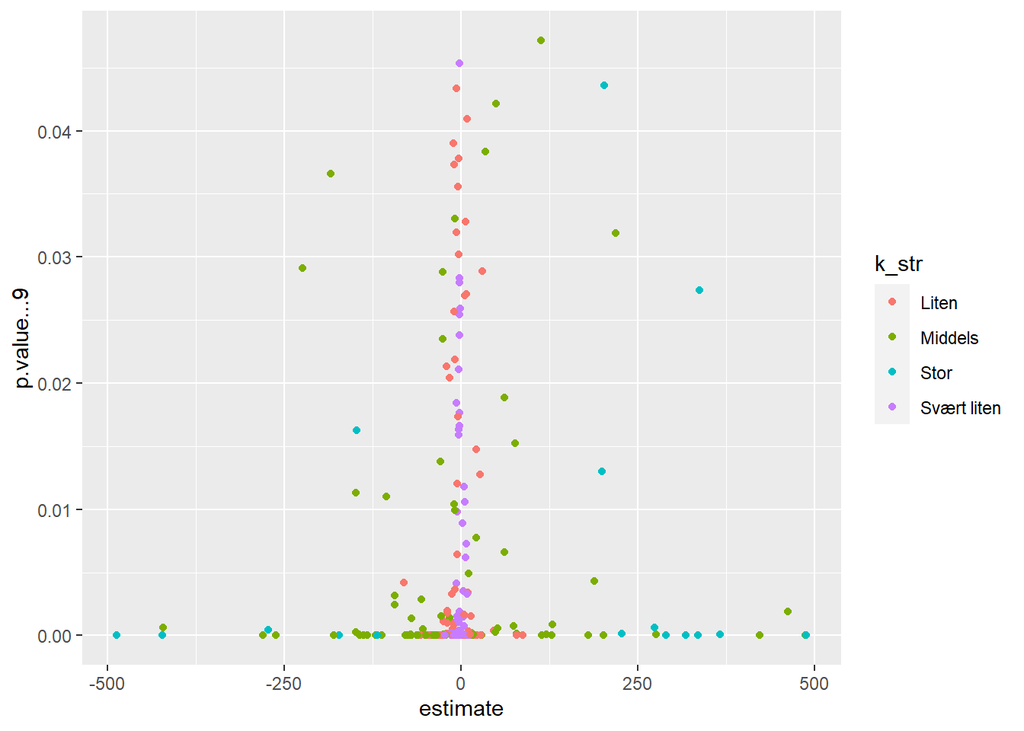

```r
kom_str_mod %>%
    filter(term == "alp_15_29") %>%
    filter(estimate > -500 & estimate < 500 ) %>%
    filter(p.value...9 < 0.05) %>%
    ggplot(mapping = aes(
        x = estimate,
        y = p.value...9,
        colour = k_str
        )
        ) +
    geom_point()
```

Lag tilsvarende plot for alp_30_74.

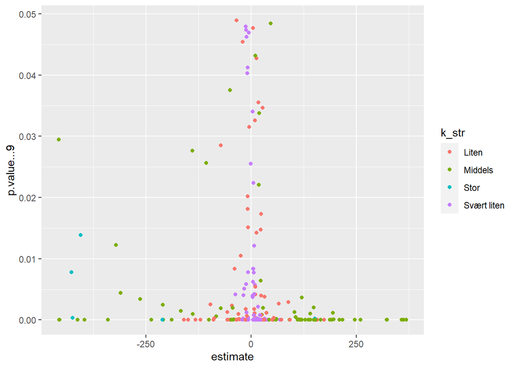

Hvor mange har vi? For å svare på dette er vi spesielt interresert i å finne ut antallet koeffisient forskjellig fra null. For å finne ut dette må vi kjøre en lineær modell hvor vi får tatt ut koeffisient data/for de to gruppene.

```r
kom_str_mod %>%
    filter(term == "alp_15_29") %>%
    group_by(k_str) %>%
    summarise(n = n())
```

```
## # A tibble: 5 x 2
##   k_str           n
##   <chr>       <int>
## 1 Liten         126
## 2 Middels       114
## 3 Stor           40
## 4 Svært liten   128
## 5 Svært stor     10
```

```r
kom_str_mod %>%
    filter(term == "alp_15_29") %>%
    filter(estimate > - 500 & estimate < 500 ) %>%
    filter(p.value...9 < 0.05) %>%
    group_by(k_str) %>%
    summarise(n = n())
```

```
## # A tibble: 4 x 2
##   k_str           n
##   <chr>       <int>
## 1 Liten          64
## 2 Middels        74
## 3 Stor           16
## 4 Svært liten    58
```

```r
kom_str_mod %>%
    filter(term == "alp_30_74") %>%
    filter(estimate > - 500 & estimate < 500 ) %>%
    filter(p.value...9 < 0.05) %>%
    group_by(k_str) %>%
    summarise(n = n())
```

```
## # A tibble: 4 x 2
##   k_str           n
##   <chr>       <int>
## 1 Liten          68
## 2 Middels        66
## 3 Stor            5
## 4 Svært liten    71
```

```r
kom_str_mod %>%
    filter(term == "alp_15_29") %>%
    filter(p.value...9 < 0.05) %>%
    group_by(k_str) %>%
    summarise(mean_15_29 = mean(estimate))
```

```
## # A tibble: 5 x 2
##   k_str       mean_15_29
##   <chr>            <dbl>
## 1 Liten            -2.93
## 2 Middels          -6.53
## 3 Stor            -18.5
## 4 Svært liten      -1.64
## 5 Svært stor    -9901.
```

```r
kom_str_mod %>%
    filter(term == "alp_30_74") %>%
    filter(p.value...9 < 0.05) %>%
    group_by(k_str) %>%
    summarise(mean_30_74 = mean(estimate))
```

```
## # A tibble: 5 x 2
##   k_str       mean_30_74
##   <chr>            <dbl>
## 1 Liten            -1.47
## 2 Middels           3.42
## 3 Stor            -10.4
## 4 Svært liten       4.75
## 5 Svært stor    11076.
```

```r
kom_str_mod %>%
    filter(term == "alp_15_29") %>%
    filter(p.value...9 < 0.05) %>%
    group_by(k_str) %>%
    summarise(n = n())
```

```
## # A tibble: 5 x 2
##   k_str           n
##   <chr>       <int>
## 1 Liten          64
## 2 Middels        74
## 3 Stor           24
## 4 Svært liten    58
## 5 Svært stor      7
```

```r
kom_str_mod %>%
    filter(term == "alp_30_74") %>%
    filter(p.value...9 < 0.05) %>%
    group_by(k_str) %>%
    summarise(n = n())
```

```
## # A tibble: 5 x 2
##   k_str           n
##   <chr>       <int>
## 1 Liten          68
## 2 Middels        69
## 3 Stor           26
## 4 Svært liten    71
## 5 Svært stor      7
```

```r
#siste
```